# Midterm Exam Review

EC 325: Econometrics

Prof. Caraher

Colby College

Mar 10, 2026

## Roadmap for Today

- **Part I:** Causality, RCTs, and the Potential Outcomes Framework (~15 min)
- **Part II:** Good Data Practices and R/Tidyverse (~20 min)
- **Part III:** Bivariate OLS — Model, Estimation, Interpretation (~20 min)
- **Part IV:** Multivariate OLS and Omitted Variable Bias (~20 min)
- **Part V:** Properties of the OLS Estimator — Assumptions and Variance (~20 min)
- **Part VI:** Statistical Inference — Hypothesis Testing through CIs (~20 min)
- **Q&A / Practice** (~5 min)

# Part I: Causality and Experimental Design

## What is Econometrics?

**Econometrics:** The practice of using statistical, quantitative methods to study social phenomena and provide insights into public policy.

- Modern econometrics focuses on identifying **causal effects** — not mere correlation
- This focus on causality is called **causal inference**

**Examples of Causal Inference Questions:**

- Does having health insurance cause you to be healthier?
- Does a college degree increase your earnings?
- Do tariffs increase domestic production?

## Steps of an Econometric Project

1. Write an econometric model
2. Get the data
3. Estimate the relationship
4. Interpret the estimates

**Key takeaway:** Econometrics is not just “running a regression” — it requires careful thinking about *what* we are estimating and *why* at every stage.

## The Core Problem: Correlation $\neq$ Causation

- **Correlation vs. Causation:** We cannot infer causality from correlation alone
  - *Example:* Health insurance coverage is correlated with better health, but this does not mean insurance *causes* better health
- **Selection Bias (Apples-to-Oranges):** Simple comparisons fail because the groups being compared differ in underlying characteristics
  - Those with insurance may also be wealthier, which independently improves health
- **Ceteris Paribus:** If we compare “apples-to-apples” (all else equal), then the difference in outcomes *can* be interpreted as a causal effect

## Concept Check: Selection Bias

> Suppose we compare average test scores of students who attend private tutoring vs. those who do not. We find tutored students score 15 points higher.

**Can we conclude tutoring causes a 15-point increase?**

**No.** Students who seek tutoring may differ in motivation, parental involvement, prior ability, etc. These are sources of **selection bias**.

## Formalizing Causality: Potential Outcomes

- **The Framework:** We denote:
  - $Y_{1i}$: treated outcome if unit $i$
  - $Y_{0i}$: untreated outcome if unit $i$
  - Causal effect: $\kappa_i = Y_{1i} - Y_{0i}$
- **Fundamental Problem of Causal Inference:** We can never observe *both* $Y_{1i}$ and $Y_{0i}$ for the same unit — we only see one outcome

## Mean Comparisons and Selection Bias

- A simple difference in group means between units $i$ in the treatment group ($D_i=1$) and control group ($D_i=0$):

$$E[Y_i | D_i = 1] - E[Y_i | D_i = 0]$$

- This decomposes into:

$$\underbrace{E[Y_{1i} | D_i = 1] - E[Y_{0i} | D_i = 1]}_{\text{Causal Effect } (\kappa)} + \underbrace{E[Y_{0i} | D_i = 1] - E[Y_{0i} | D_i = 0]}_{\text{Selection Bias}}$$

- **Selection Bias Term:** Captures how the treated group *would have fared without treatment* ($E[Y_{0i} | D_i = 1]$) vs. the control group ($E[Y_{0i} | D_i = 0]$) — usually driven by pre-existing differences or trends (e.g., wealth, health preferences)

## The Gold Standard: RCTs

- **Randomized Control Trials (RCTs):** Randomly assign units to treatment or control
- **Why Randomization Works:**
  - The **Law of Large Numbers (LLN)** ensures that, with a large enough sample, background characteristics are balanced across groups
  - Formally: $E[Y_{0i} | D_i = 1] = E[Y_{0i} | D_i = 0]$, so selection bias = 0
- **Example:** The **Oregon Health Insurance Experiment** used a lottery to randomly assign Medicaid eligibility, allowing researchers to estimate the causal effect of health insurance

## Quick Recap: Part I

| Concept | Key Idea |
| --- | --- |
| Econometrics | Causal inference using statistical methods |
| Selection Bias | Groups differ in unobservable ways |
| Potential Outcomes | $\kappa = Y_{1i} - Y_{0i}$, but we only see one |
| RCTs | Randomization eliminates selection bias via LLN |

# Part II: Good Data Practices and R

## Why Good Data Practices Matter

- Before running any regression, you must **get to know your data**
- Reinhart-Rogoff (2010): influential research on debt and economic growth contained spreadsheet errors
  - Errors discovered by a grad student attempting to replicate the results
  - Corrected results told a **very different** policy story

**The Lesson**

No sophisticated econometric technique can compensate for errors in the underlying data.

## Key Questions to Ask About Your Data

Before any analysis:

1. **How many observations?** Is anything missing?
2. **Is the distribution reasonable?** Do the mean, min, and max make sense?
3. **Are there outliers or impossible values?**

Tools:

- **Descriptive statistics:** `mean()`, `sd()`, `min()`, `max()`, `summary()`
- **Visualizations:** histograms, scatterplots via `ggplot2`

## Missing Data

- Many R functions return `NA` if any value is missing
- Use `is.na()` and `sum(is.na())` to detect missing values
- Use `na.rm = TRUE` to ignore them in calculations:

```r
mean(airquality$Ozone)             # Returns NA
mean(airquality$Ozone, na.rm = TRUE)  # Ignores NAs
```

- **Caution:** Data can be **missing systematically** (not at random)
  - High earners refusing to report income $\rightarrow$ underestimates average income
  - Sicker patients dropping out of a study $\rightarrow$ remaining sample looks healthier

## R Basics You Should Know

| Concept | Syntax | What It Does |
| --- | --- | --- |
| Assignment | `x <- 3` | Stores value as an object |
| Vectors | `c(1, 2, 3)` | Combines values into a sequence |
| Functions | `mean(x)` | Applies a pre-built operation |
| Data frames | `mtcars` | Rows = observations, columns = variables |
| Column access | `mtcars$mpg` | Extracts a single column |
| Data types | numeric, character, logical, factor | Determines what operations are valid |
| Packages | `library(tidyverse)` | Loads a package of functions |

## The Pipe Operator: `|>`

- Takes whatever is on the **left** and passes it as the **first argument** to the function on the **right**
- Read it as **“and then”**

```r
# Take mtcars AND THEN filter to high-mpg cars
mtcars |>
  filter(mpg > 25)
```

```
                mpg cyl  disp  hp drat    wt  qsec vs am gear carb
Fiat 128       32.4   4  78.7  66 4.08 2.200 19.47  1  1    4    1
Honda Civic    30.4   4  75.7  52 4.93 1.615 18.52  1  1    4    2
Toyota Corolla 33.9   4  71.1  65 4.22 1.835 19.90  1  1    4    1
Fiat X1-9      27.3   4  79.0  66 4.08 1.935 18.90  1  1    4    1
Porsche 914-2  26.0   4 120.3  91 4.43 2.140 16.70  0  1    5    2
Lotus Europa   30.4   4  95.1 113 3.77 1.513 16.90  1  1    5    2
```

## Key `dplyr` Functions

| Function | Purpose | Example |
| --- | --- | --- |
| `filter()` | Subset **rows** by condition | `filter(mpg > 25)` |
| `select()` | Choose **columns** | `select(mpg, cyl, wt)` |
| `mutate()` | Create/modify **variables** | `mutate(kmpl = mpg * 0.425)` |
| `summarize()` | Collapse to **summary stats** | `summarize(avg = mean(mpg))` |
| `group_by()` | Group data before summarizing | `group_by(cyl)` |
| `arrange()` | Sort rows | `arrange(desc(mpg))` |
| `count()` | Count rows per group | `count(cyl)` |

Each verb does **one thing** well. The pipe `|>` chains them together.

## `filter()` and `select()`

**`filter()`:** Keep rows meeting a condition

```r
mtcars |> filter(cyl == 4, mpg > 25)
```

```
                mpg cyl  disp  hp drat    wt  qsec vs am gear carb
Fiat 128       32.4   4  78.7  66 4.08 2.200 19.47  1  1    4    1
Honda Civic    30.4   4  75.7  52 4.93 1.615 18.52  1  1    4    2
Toyota Corolla 33.9   4  71.1  65 4.22 1.835 19.90  1  1    4    1
Fiat X1-9      27.3   4  79.0  66 4.08 1.935 18.90  1  1    4    1
Porsche 914-2  26.0   4 120.3  91 4.43 2.140 16.70  0  1    5    2
Lotus Europa   30.4   4  95.1 113 3.77 1.513 16.90  1  1    5    2
```

**`select()`:** Choose (or drop) specific columns

```r
mtcars |> select(mpg, cyl, wt) |> head(4)
```

```
                mpg cyl    wt
Mazda RX4      21.0   6 2.620
Mazda RX4 Wag  21.0   6 2.875
Datsun 710     22.8   4 2.320
Hornet 4 Drive 21.4   6 3.215
```

## `mutate()`

**Purpose:** Create new variables or transform existing ones

```r
mtcars |>
  mutate(kmpl = mpg * 0.425) |>
  select(mpg, kmpl) |>
  head(5)
```

```
                   mpg   kmpl
Mazda RX4         21.0 8.9250
Mazda RX4 Wag     21.0 8.9250
Datsun 710        22.8 9.6900
Hornet 4 Drive    21.4 9.0950
Hornet Sportabout 18.7 7.9475
```

## Chaining Verbs Together

- The real power: **chain multiple operations** in sequence
- Read like a sentence: “Take the data, *then* filter, *then* mutate, *then* select…”

```r
mtcars |>
  filter(cyl == 4) |>
  mutate(kmpl = mpg * 0.425) |>
  select(mpg, kmpl, wt)
```

```
                mpg    kmpl    wt
Datsun 710     22.8  9.6900 2.320
Merc 240D      24.4 10.3700 3.190
Merc 230       22.8  9.6900 3.150
Fiat 128       32.4 13.7700 2.200
Honda Civic    30.4 12.9200 1.615
Toyota Corolla 33.9 14.4075 1.835
Toyota Corona  21.5  9.1375 2.465
Fiat X1-9      27.3 11.6025 1.935
Porsche 914-2  26.0 11.0500 2.140
Lotus Europa   30.4 12.9200 1.513
Volvo 142E     21.4  9.0950 2.780
```

## `summarize()` and `group_by()`

**`summarize()`:** Collapse a data frame into summary statistics

```r
mtcars |>
  summarize(mean_mpg = mean(mpg), sd_mpg = sd(mpg), n = n())
```

```
  mean_mpg   sd_mpg  n
1 20.09062 6.026948 32
```

**`group_by()` + `summarize()`:** Compute stats **by group**

```r
mtcars |>
  group_by(cyl) |>
  summarize(mean_mpg = mean(mpg), mean_hp = mean(hp), n = n())
```

```
# A tibble: 3 × 4
    cyl mean_mpg mean_hp     n
  <dbl>    <dbl>   <dbl> <int>
1     4     26.7    82.6    11
2     6     19.7   122.      7
3     8     15.1   209.     14
```

## `count()` and `arrange()`

**`count()`:** Quickly tally rows per group

```r
mtcars |> count(cyl)
```

```
  cyl  n
1   4 11
2   6  7
3   8 14
```

**`arrange()`:** Sort rows (use `desc()` for descending)

```r
mtcars |> arrange(desc(mpg)) |> select(mpg, cyl, hp) |> head(4)
```

```
                mpg cyl  hp
Toyota Corolla 33.9   4  65
Fiat 128       32.4   4  66
Honda Civic    30.4   4  52
Lotus Europa   30.4   4 113
```

## Quick Overview Tools

**`summary()`:** Min, quartiles, mean, max for every column

```r
summary(mtcars[, 1:4])
```

```
      mpg             cyl             disp             hp
 Min.   :10.40   Min.   :4.000   Min.   : 71.1   Min.   : 52.0
 1st Qu.:15.43   1st Qu.:4.000   1st Qu.:120.8   1st Qu.: 96.5
 Median :19.20   Median :6.000   Median :196.3   Median :123.0
 Mean   :20.09   Mean   :6.188   Mean   :230.7   Mean   :146.7
 3rd Qu.:22.80   3rd Qu.:8.000   3rd Qu.:326.0   3rd Qu.:180.0
 Max.   :33.90   Max.   :8.000   Max.   :472.0   Max.   :335.0
```

**`glimpse()`:** Variable names, types, and first few values

```r
glimpse(mtcars)
```

```
Rows: 32
Columns: 11
$ mpg  <dbl> 21.0, 21.0, 22.8, 21.4, 18.7, 18.1, 14.3, 24.4, 22.8, 19.2, 17.8,…
$ cyl  <dbl> 6, 6, 4, 6, 8, 6, 8, 4, 4, 6, 6, 8, 8, 8, 8, 8, 8, 4, 4, 4, 4, 8,…
$ disp <dbl> 160.0, 160.0, 108.0, 258.0, 360.0, 225.0, 360.0, 146.7, 140.8, 16…
$ hp   <dbl> 110, 110, 93, 110, 175, 105, 245, 62, 95, 123, 123, 180, 180, 180…
$ drat <dbl> 3.90, 3.90, 3.85, 3.08, 3.15, 2.76, 3.21, 3.69, 3.92, 3.92, 3.92,…
$ wt   <dbl> 2.620, 2.875, 2.320, 3.215, 3.440, 3.460, 3.570, 3.190, 3.150, 3.…
$ qsec <dbl> 16.46, 17.02, 18.61, 19.44, 17.02, 20.22, 15.84, 20.00, 22.90, 18…
$ vs   <dbl> 0, 0, 1, 1, 0, 1, 0, 1, 1, 1, 1, 0, 0, 0, 0, 0, 0, 1, 1, 1, 1, 0,…
$ am   <dbl> 1, 1, 1, 0, 0, 0, 0, 0, 0, 0, 0, 0, 0, 0, 0, 0, 0, 1, 1, 1, 0, 0,…
$ gear <dbl> 4, 4, 4, 3, 3, 3, 3, 4, 4, 4, 4, 3, 3, 3, 3, 3, 3, 4, 4, 4, 3, 3,…
$ carb <dbl> 4, 4, 1, 1, 2, 1, 4, 2, 2, 4, 4, 3, 3, 3, 4, 4, 4, 1, 2, 1, 1, 2,…
```

## Visualization with `ggplot2`

- Every ggplot is built **layer by layer:**
1. Start with data: `ggplot(data)`
2. Add geometry: `geom_point()`, `geom_histogram()`, `geom_smooth()`, `geom_col()`
3. Map variables to aesthetics: `aes(x = ..., y = ..., color = ...)`
4. Add labels: `labs(title = ..., x = ..., y = ...)`

| Function | What It Does |
| --- | --- |
| `ggplot(data)` | Initialize plot |
| `aes(x, y, color)` | Map variables to aesthetics |
| `geom_point()` | Scatterplot |
| `geom_smooth(method = "lm")` | Line of best fit |
| `geom_histogram()` | Histogram |
| `geom_col()` | Bar chart |
| `labs()` | Labels and titles |

## `ggplot2` Example

```r
ggplot(data = mtcars) +
  geom_point(aes(x = wt, y = mpg, color = factor(cyl))) +
  geom_smooth(aes(x = wt, y = mpg), method = "lm") +
  labs(title = "MPG vs. Weight", x = "Weight (1000 lbs)",
       y = "Miles per Gallon", color = "Cylinders") +
  theme_minimal()
```

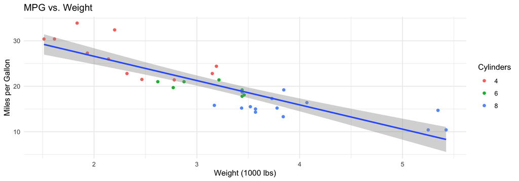

## Saving Your Work

- Always work in **scripts** (`.R` files), not the console — scripts are saveable and replicable
- Use **R Projects** (`.Rproj`) so your working directory is set automatically
- **Comment your code** with `#` to explain what it does and *why*

**The Replication Standard**

Research meets the replication standard when an independent researcher can exactly duplicate the results using only the information provided.

# Part III: Bivariate OLS

## Conditional Expectations

- **Conditional expectation:** Our “best guess” of $Y$ given that $X$ takes some value $x$:

$$E[Y | X = x]$$

- *Example:* What is the expected wage for those with a college degree ($X = BA$)?
- This is the quantity that OLS attempts to estimate

## The Population Regression Model (Bivariate)

- When RCTs are not feasible, we use **Ordinary Least Squares (OLS)** regression:

$$y = \beta_0 + \beta_1 x + \mu$$

- $y$: Dependent variable (outcome/response)
- $x$: Independent variable (explanatory/predictor)
- $\mu$: Error term (all unobserved factors affecting $y$)
- $\beta_0, \beta_1$: Population parameters (“true”, unknowable values)

## The OLS Regression Line

- We estimate the unknown population parameters using sample data, yielding $\hat{\beta}_0$ and $\hat{\beta}_1$:

$$\hat{y} = \hat{\beta}_0 + \hat{\beta}_1 x$$

- $\hat{\beta}_0$: Predicted value of $y$ when $x = 0$ (the intercept)
- $\hat{\beta}_1$: **Marginal effect** — the predicted change in $y$ when $x$ increases by 1 unit

$$\Delta \hat{y} = \hat{\beta}_1 \cdot \Delta x$$

## Deriving the OLS Estimates

- OLS chooses $\hat{\beta}_0$ and $\hat{\beta}_1$ to minimize the **Sum of Squared Residuals (SSR)**:

$$SSR = \sum_{i=1}^{n}(y_i - \hat{y}_i)^2 = \sum_{i=1}^{n}\hat{\mu}_i^2$$

- The slope estimate:

$$\hat{\beta}_1 = \frac{\sum_{i=1}^{n}(x_i - \bar{x})(y_i - \bar{y})}{\sum_{i=1}^{n}(x_i - \bar{x})^2} = \frac{Cov(x,y)}{Var(x)}$$

- The intercept: $\hat{\beta}_0 = \bar{y} - \hat{\beta}_1 \bar{x}$

## Correlation and the Slope Coefficient

- The bivariate OLS slope can be re-written as the **scaled correlation** between $x$ and $y$:

$$\hat{\beta}_1 = \rho_{xy} \frac{\sigma_y}{\sigma_x}$$

- Because $\hat{\beta}_1$ relies heavily on correlation, **caution is needed** when inferring causality from bivariate OLS

## Goodness-of-Fit: $R^2$

- **$R^2$** measures the fraction of total variation in $y$ explained by the model:

$$R^2 = \frac{SSE}{SST} = 1 - \frac{SSR}{SST}$$

- $SST = \sum(y_i - \bar{y})^2$: Total Sum of Squares (total variation in $y$)
- $SSE = \sum(\hat{y}_i - \bar{y})^2$: Explained Sum of Squares
- $SSR = \sum(y_i - \hat{y}_i)^2$: Residual (unexplained) Sum of Squares
- $R^2$ ranges from 0 to 1; higher values indicate a better fit

## Concept Check: Bivariate OLS

> You estimate: $\widehat{wage} = 5.2 + 1.8 \cdot educ$
- What is the predicted wage for someone with 16 years of education?
  - $5.2 + 1.8(16) = 34.0$
- What is the marginal effect of one additional year of education?
  - $\$1.80$ per hour
- Can we interpret 1.8 as the *causal effect* of education on wages?
  - **Not necessarily** — bivariate OLS is susceptible to **omitted variable bias**

# Part IV: Multivariate OLS and OVB

## Why Multivariate OLS?

- Bivariate OLS is susceptible to **Omitted Variable Bias (OVB)**
- OVB occurs when:
  1. A variable affecting $y$ is excluded from the model, **AND**
  2. That excluded variable is correlated with an included variable ($x$)
- This violates the **Zero Conditional Mean** assumption
- **Solution:** Include additional control variables using multivariate OLS

## The Multivariate OLS Model

$$y = \beta_0 + \beta_1 x_1 + \beta_2 x_2 + \dots + \beta_k x_k + \mu$$

- **Interpretation:** Each $\hat{\beta}_j$ gives the **ceteris paribus** effect of $x_j$ on $y$, holding all other included variables constant
- By controlling for confounders, multivariate OLS moves us closer to plausibly causal estimates

## Multivariate OLS as Matching

- Multivariate OLS can be thought of as a **matching estimator**:
  - It matches observations on control variables and then computes a weighted average of the effect across groups
- *Example (Gender Wage Gap):* Controlling for industry, the OLS coefficient on “female” approximates the weighted average of the within-industry gender wage gap

## The OVB Formula

- If we omit $x_2$ from a model that should include it, the biased estimate $\tilde{\beta}_1$ from the short regression relates to the true $\beta_1$:

$$E[\tilde{\beta}_1] = \beta_1 + \beta_2 \cdot \delta_1$$

where $Bias(\tilde{\beta}_1) = \beta_2 \cdot \delta_1$

- $\beta_2$: Effect of the omitted variable on $y$
- $\delta_1$: Correlation between the omitted variable and the included variable

## Direction of OVB

| $Corr(x_1, x_2)$ | $\beta_2 > 0$ | $\beta_2 < 0$ |
| --- | --- | --- |
| $\delta_1 > 0$ (Positive) | **Positive Bias** ($\tilde{\beta}_1$ too large) | **Negative Bias** ($\tilde{\beta}_1$ too small) |
| $\delta_1 < 0$ (Negative) | **Negative Bias** | **Positive Bias** |

**Example (Wages & Education):**

- Omitted: Ability. Included: Education. Outcome: Wage
- $\beta_2 > 0$ (ability $\uparrow$ wages) and $\delta_1 > 0$ (ability $\uparrow$ education)
- Result: **Positive bias** — bivariate OLS *overstates* the return to education

## Concept Check: OVB

> You estimate a bivariate regression of health outcomes on exercise frequency. You suspect that income is omitted.

**What is the likely direction of the bias?**

- $\beta_2 > 0$: Higher income $\rightarrow$ better health (through nutrition, healthcare access, etc.)
- $\delta_1 > 0$: Higher income $\rightarrow$ more exercise (gym memberships, leisure time)
- Bias $= \beta_2 \cdot \delta_1 > 0$: **Positive bias** — the bivariate estimate overstates the effect of exercise

## Adjusted $R^2$

- In multivariate OLS, $R^2$ mechanically increases when adding variables — even irrelevant ones
- **Adjusted $R^2$** penalizes for additional parameters:

$$\bar{R}^2 = 1 - \frac{SSR/(n-k-1)}{SST/(n-1)}$$

- $\bar{R}^2 \leq R^2$ always, and can decrease if an added variable is not useful
- Preferred measure of fit in multivariate models

# Part V: Properties of the OLS Estimator

## The Gauss-Markov Assumptions

The first four assumptions ensure OLS is **unbiased**: $E[\hat{\beta}_j] = \beta_j$

## GM Assumption 1: Linearity in Parameters

**GM 1: Linearity in Parameters**

The model is linear in the $\beta$ parameters:
$$y = \beta_0 + \beta_1 x_1 + \beta_2 x_2 + \dots + \beta_k x_k + \mu$$

- Non-linear transformations of the *data* are fine (e.g., $\log(y)$, $x^2$)
- Only need linearity in the $\beta$’s

## GM Assumption 2: Random Sampling

**GM 2: Random Sampling**

We have a random sample of size $n$: $\{(y_i, x_{1i}, x_{2i}, \dots, x_{ki}) : i = 1, 2, \dots, n\}$ from the population.

## GM Assumption 3: No Perfect Multicollinearity

**GM 3: No Perfect Multicollinearity**

None of the independent variables are constant, and there is no exact linear relationship among the independent variables.

- **Violation** occurs if one variable is an exact linear function of another
- *Example:* Including both “age” and “birth year” in a cross-section
- Note: High (but imperfect) correlation is allowed but inflates variance

## GM Assumption 4: Zero Conditional Mean

**GM 4: Zero Conditional Mean (ZCM)**

$$E[\mu | x_1, x_2, \dots, x_k] = 0$$

- **The most important assumption for causal inference**
- All factors in $\mu$ must be uncorrelated with the $x$ variables
- Violated most commonly by **omitted variable bias**

## GM 1–4: Unbiasedness

- If GM 1–4 hold, the OLS estimator is **unbiased:**

$$E[\hat{\beta}_j] = \beta_j$$

- On average (across many hypothetical samples), the OLS estimate equals the true population parameter

## GM Assumption 5: Homoskedasticity

**GM 5: Homoskedasticity**

$$Var(\mu | x_1, \dots, x_k) = \sigma^2$$

- The error variance is constant across all values of $x$
- **Heteroskedasticity:** When this assumption fails (variance of $\mu$ depends on $x$)
- If **GM 1–5** all hold, OLS is **BLUE** (Best Linear Unbiased Estimator) — it has the lowest variance among all linear unbiased estimators

## Variance of $\hat{\beta}_j$

- Under GM 1–5, the variance of the multivariate OLS estimator is:

$$Var(\hat{\beta}_j) = \frac{\sigma^2}{SST_j(1 - R_j^2)} \quad \text{for } j = 1, 2, \dots, k$$

where:

- $\sigma^2$: Population error variance
- $SST_j = \sum(x_{ji} - \bar{x}_j)^2$: Sample variation in $x_j$
- $R_j^2$: $R^2$ from regressing $x_j$ on all other independent variables

## The Problem: $\sigma^2$ is Unknown

- We want to compute the standard error, but the variance formula contains $\sigma^2$ — a **population parameter** we cannot observe
- We need to estimate $\sigma^2$ from our sample data
- **Starting point:** From homoskedasticity (GM 5) and zero conditional mean (GM 4):

$$Var(\mu_i | x_i) = \sigma^2 \quad \text{and} \quad E[\mu_i] = 0$$

- Combining these:

$$Var(\mu_i) = E[(\mu_i - E[\mu_i])^2] = E[(\mu_i - 0)^2] = E[\mu_i^2]$$

- So to estimate $\sigma^2$, we need a good estimate of the **error terms** $\mu_i$

## Estimating $\sigma^2$ from the Residuals

- We can’t observe the true errors $\mu_i$, but we *can* compute the **residuals:**

$$\hat{\mu}_i = y_i - \hat{y}_i$$

- The residuals are our sample analog of the population errors
- It turns out that the average squared residual (adjusted for degrees of freedom) is an **unbiased estimator** of $\sigma^2$:

$$\hat{\sigma}^2 = \frac{\sum_{i=1}^{n}\hat{\mu}_i^2}{n - k - 1} = \frac{SSR}{n - k - 1}$$

- We divide by $n - k - 1$ (not $n$) because estimating $k + 1$ parameters ($\beta_0, \beta_1, \dots, \beta_k$) “uses up” $k + 1$ degrees of freedom

## From $\hat{\sigma}^2$ to the Standard Error

- Now we can plug $\hat{\sigma}^2$ into our variance formula and take the square root to get the **standard error:**

$$se(\hat{\beta}_j) = \frac{\hat{\sigma}}{\sqrt{SST_j(1 - R_j^2)}}$$

- The standard error is the estimated standard deviation of the sampling distribution of $\hat{\beta}_j$
- It measures the **precision** of our estimate

**The Key Chain of Logic**

$$Var(\hat{\beta}_j) = \frac{\sigma^2}{SST_j(1-R_j^2)} \xrightarrow{\text{estimate } \sigma^2 \text{ with residuals}} se(\hat{\beta}_j) = \frac{\hat{\sigma}}{\sqrt{SST_j(1-R_j^2)}}$$
We go from a formula involving an unknown population parameter ($\sigma^2$) to a computable standard error by replacing $\sigma^2$ with its sample estimate $\hat{\sigma}^2 = SSR/(n-k-1)$.

## What Affects the Standard Error?

Three factors determine the precision of $\hat{\beta}_j$:

1. **Error variance ($\sigma^2$):** More noise in $y$ $\rightarrow$ higher standard error
2. **Sample variation in $x_j$ ($SST_j$):** More variation in $x_j$ $\rightarrow$ lower standard error (more information)
3. **Multicollinearity ($R_j^2$):** Higher correlation among $x$’s $\rightarrow$ higher standard error (less independent info in $x_j$)

**Also:** Larger sample size ($n$) increases $SST_j$, reducing the standard error

## The Bias/Variance Tradeoff

- Including more controls: reduces bias (satisfies ZCM) but can increase variance if controls are correlated with $x_1$
- Omitting relevant controls: reduces variance but introduces bias
- **Larger samples** alleviate the tradeoff: variance shrinks with $n$, making it safer to include more controls

# Part VI: Statistical Inference

## The Big Picture

- We have one estimate $\hat{\beta}_j$ from one sample
- **Question:** Does this estimate reflect something “real” about the population, or is it just noise from random sampling?
- **Statistical inference** provides the tools to answer this question

## The Normality Assumption

**Normality**

The population error $\mu$ is independent of $x_1, \dots, x_k$ and is normally distributed:

. . .

$$\mu \sim Normal(0, \sigma^2)$$

- This implies a **normal sampling distribution** for the OLS estimator:

$$\hat{\beta}_j \sim Normal\left[\beta_j, \; Var(\hat{\beta}_j)\right]$$

## Hypothesis Testing: The Logic

- **Null Hypothesis** ($H_0$): Typically $\beta_j = 0$ (the variable has no effect)
- **Alternative Hypothesis** ($H_A$): Typically $\beta_j \neq 0$

**The procedure:**

1. **Assume** the null is true ($\beta_j = 0$)
2. **Construct** the distribution of estimates we would expect *if the null were true*
3. **Check** whether our actual estimate is unlikely under the null
4. If very unlikely $\rightarrow$ **reject $H_0$** in favor of $H_A$

## The T-Statistic

$$t_{\hat{\beta}_j} = \frac{\hat{\beta}_j}{se(\hat{\beta}_j)}$$

- Measures how many standard errors the estimate is from zero
- If $|t|$ is “large,” our estimate is unlikely under $H_0$
- Under $H_0$ and GM 1–6, the $t$-statistic follows a $t_{n-k-1}$ distribution

## The Decision Rule

1. Choose a significance level $\alpha$ (common choices: 0.10, 0.05, 0.01)
2. Find the **critical value** $c_\alpha$ from the $t_{n-k-1}$ distribution
3. **Reject $H_0$** if $|t_{\hat{\beta}_j}| > c_\alpha$

**Where does $c_\alpha$ come from?**

- In principle, from a $t$-distribution table using $n - k - 1$ degrees of freedom
- In practice, R computes it for us — `summary(lm(...))` reports the $t$-statistic and p-value directly

**Rule-of-Thumb (Large Samples):** As $n \rightarrow \infty$, the $t$ distribution approaches the standard normal, so $c_{0.05} \approx 1.96 \approx 2$. If $|t| > 2$, the estimate is (usually) statistically significant at the 5% level.

## Statistical Significance: Key Points

- **Language matters:** When we cannot reject $H_0$, we say we **“fail to reject the null”** — *not* that we “accept the null”

## Concept Check: Hypothesis Testing

> You estimate: $\hat{\beta}_1 = 0.45$ with $se(\hat{\beta}_1) = 0.20$
- $t = 0.45 / 0.20 = 2.25$
- Since $|t| ~> 2$: statistically significant at the 5% level
- We **reject** $H_0: \beta_1 = 0$

> Now suppose $\hat{\beta}_1 = 0.003$ with $se(\hat{\beta}_1) = 0.001$, so $t = 3.0$
- Statistically significant, but is $0.003$ economically meaningful? **Context matters.**

# Putting It All Together

## The Big Picture: From Causality to Inference

1. **Start** with a causal question
2. **Check your data** — descriptive stats, visualizations, missing values
3. **Ideally** use an RCT; if not, use multivariate OLS with controls
4. **Verify** assumptions (especially ZCM — think about OVB)
5. **Estimate** and conduct inference (t-tests)
6. **Interpret** carefully: statistical significance $\neq$ practical significance

## Key Formulas to Know

| Formula | What It Measures |
| --- | --- |
| $\hat{\beta}_1 = \frac{Cov(x,y)}{Var(x)}$ | OLS slope estimate |
| $Bias = \beta_2 \cdot \delta_1$ | Omitted variable bias |
| $Var(\hat{\beta}_j) = \frac{\sigma^2}{SST_j(1-R_j^2)}$ | Estimator variance |
| $se(\hat{\beta}_j) = \frac{\hat{\sigma}}{\sqrt{SST_j(1-R_j^2)}}$ | Standard error |
| $t = \frac{\hat{\beta}_j}{se(\hat{\beta}_j)}$ | T-statistic |

## Key R Functions to Know

| Task | Functions |
| --- | --- |
| Subset rows | `filter()` |
| Choose columns | `select()` |
| Create variables | `mutate()` |
| Summarize data | `summarize()`, `group_by()` |
| Count observations | `count()`, `n()` |
| Sort data | `arrange()`, `desc()` |
| Descriptive stats | `mean()`, `sd()`, `min()`, `max()`, `summary()` |
| Handle missing data | `is.na()`, `sum(is.na())`, `na.rm = TRUE` |
| Visualize | `ggplot()`, `geom_point()`, `geom_histogram()`, `geom_smooth()` |
| Chain operations | `\|>` (pipe) |

## Good Luck!

- Review the study guide for a complete topic list
- Practice interpreting regression output
- Think through OVB examples — they are a favorite exam topic
- Practice writing and reading `tidyverse` code
- Remember: the goal is to understand the *logic* behind each method, not just memorize formulas